# Project Business Statistics: E-news Express

**Marks: 60**

## Define Problem Statement and Objectives

### Business Context

The advent of e-news, or electronic news portals has offered us a great opportunity to quickly get updates on the day-to-day event ocurring globally. The information on these portals is retrieved electronically from online databases, processed using a variety of software, and then transmitted to the users. There are multiple advantages of transmitting news electronically, like faster access to the content and ability to utilize different technologies such as audio, graphics, video, and other interactive elements that are either not being used or aren't common yet in traditional newspapers.

E-news Express, an online news portal, aims to expand its business by acquiring new subscribers. With every visitor to the website taking certain actions based on their interest, the company plans to analyze these actions to understand user interests and determine how to drive better engagement. the executives at E-new Express are of the opinion that there has been a decline in new monthly susbscribers compared to the past year because the current webpage is not designed well enough in terms of the outline and recommended content to keep customers engaged long enough to make a decision to subscribe.

### Objective

The design team of the company has researched and created a new landing page that has a new outline & more relevant content shown compared to the old page. In order to test the effectiveness of the new landing page in gathering new subscribers, the Data Science team conducted an experiment by randomly selecting 100 users and dividing them equally into two groups. The existing landing page was served to the first group (control group) and the new landing page to the second group (treatment group). Data regarding the interaction of users in both groups with the two versions of the landing page was collected. Being a data scientist in E-news Express, you have been asked to explore the data and perform a statistical analysis (at a significance level of 5%) to determine the effectiveness of the new landing page in gathering new subscribers for the news portal by answering the following questions:

1. Do the users spend more time on the new landing page than on the existing landing page?
2. Is the conversion rate (the proportion of users who visit the landing page and get converted) for the new page greater than the conversion rate for the old page?
3. Does the converted status depend on the preferred language?
4. Is the time spent on the new page the same for the different language users?

### Data Dictionary

The data contains information regarding the interaction of users in both groups with the two versions of the landing page.

- user_id - Unique user ID of the person visiting the website
- group - Whether the user belongs to the first group (control) or the second group (treatment)
- landing_page - Whether the landing page is new or old
- time_spent_on_the_page - Time (in minutes) spent by the user on the landing page
- converted - Whether the user gets converted to a subscriber of the news portal or not
- language_preferred - Language chosen by the user to view the landing page

## Import all the necessary libraries

```python
import pandas as pd #library used for data manipulation and analysis
import numpy as np # library used for working with arrays
import matplotlib.pyplot as plt # library for plots and visualisations
import seaborn as sns # library for visualisations
%matplotlib inline

import scipy.stats as stats # this library contains a large number of probability distributions as well as a growing library of statistical functions
```

## Reading the Data into a DataFrame

```python
df = pd.read_csv('abtest.csv')
```

## Explore the dataset and extract insights using Exploratory Data Analysis

- Data Overview
  - Viewing the first and last few rows of the dataset
  - Checking the shape of the dataset
  - Getting the statistical summary for the variables
- Check for missing values
- Check for duplicates

### Data Overview

```python
# view first 5 rows of the dataset
df.head()
```

|  | user_id | group | landing_page | time_spent_on_the_page | converted | language_preferred |
| --- | --- | --- | --- | --- | --- | --- |
| 0 | 546592 | control | old | 3.48 | no | Spanish |
| 1 | 546468 | treatment | new | 7.13 | yes | English |
| 2 | 546462 | treatment | new | 4.40 | no | Spanish |
| 3 | 546567 | control | old | 3.02 | no | French |
| 4 | 546459 | treatment | new | 4.75 | yes | Spanish |

```python
# view last 5 rows of dataset
df.tail()
```

|  | user_id | group | landing_page | time_spent_on_the_page | converted | language_preferred |
| --- | --- | --- | --- | --- | --- | --- |
| 95 | 546446 | treatment | new | 5.15 | no | Spanish |
| 96 | 546544 | control | old | 6.52 | yes | English |
| 97 | 546472 | treatment | new | 7.07 | yes | Spanish |
| 98 | 546481 | treatment | new | 6.20 | yes | Spanish |
| 99 | 546483 | treatment | new | 5.86 | yes | English |

```python
# view how many rows and columns are in the data set
df.shape
```

```
(100, 6)
```

```python
df.info()
```

```
<class 'pandas.core.frame.DataFrame'>
RangeIndex: 100 entries, 0 to 99
Data columns (total 6 columns):
 #   Column                  Non-Null Count  Dtype
---  ------                  --------------  -----
 0   user_id                 100 non-null    int64
 1   group                   100 non-null    object
 2   landing_page            100 non-null    object
 3   time_spent_on_the_page  100 non-null    float64
 4   converted               100 non-null    object
 5   language_preferred      100 non-null    object
dtypes: float64(1), int64(1), object(4)
memory usage: 4.8+ KB
```

```python
df['time_spent_on_the_page'].describe()
```

```
count    100.000000
mean       5.377800
std        2.378166
min        0.190000
25%        3.880000
50%        5.415000
75%        7.022500
max       10.710000
Name: time_spent_on_the_page, dtype: float64
```

```python
df['group'].describe()
```

```
count         100
unique          2
top       control
freq           50
Name: group, dtype: object
```

#### Observations

- The data frame is conformed by 100 rows and 6 columns.
- The **maximum** time spent on the page is **10.71** minutes.
- The **minimum** time spent on the page is **0.19** minutes.
- The **average** time spent on the page is **5.38** minutes.
- All the columns have 100 observations, meaning there are no missing values.
- The dataset has 2 numerical columns and 4 object type columns.

### Check for missing values

```python
# check for missing values
df.isnull().sum()
```

```
user_id                   0
group                     0
landing_page              0
time_spent_on_the_page    0
converted                 0
language_preferred        0
dtype: int64
```

#### Observations

- There are no missing values in the data frame

### Check for duplicate values

```python
#check for duplicate values
df.duplicated().sum()
```

```
0
```

#### Observations

- There are no duplicate values in the data frame

### Univariate Analysis

#### User ID

```python
# check unique values for user id
df['user_id'].nunique()
```

```
100
```

- There are 100 different users in the data set

#### Group

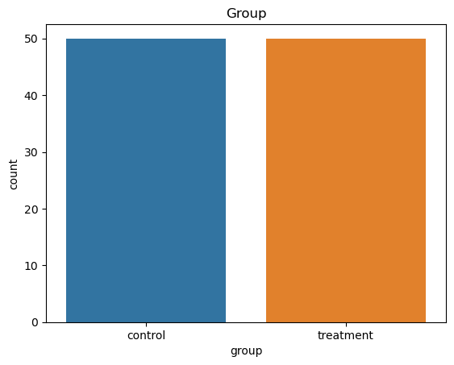

```python
sns.countplot(data=df, x='group')
plt.title('Group')
plt.show()
```

```python
df['group'].value_counts()
```

```
control      50
treatment    50
Name: group, dtype: int64
```

- The users are divided equally into two groups: 50 in control and 50 in treatment

#### Landing Page

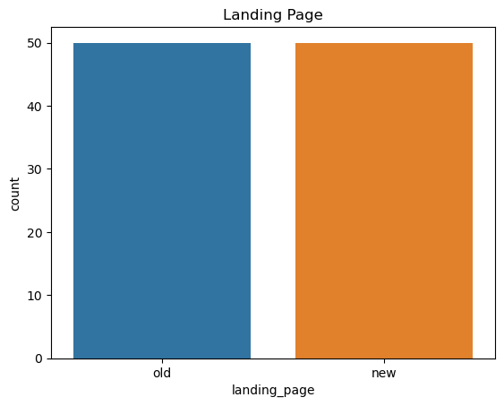

```python
sns.countplot(data=df, x='landing_page')
plt.title('Landing Page')
plt.show()
```

```python
df['landing_page'].value_counts()
```

```
old    50
new    50
Name: landing_page, dtype: int64
```

- The number of users using the old landing page is 50, as well as the ones using the new landing page.

#### Time spent on the page

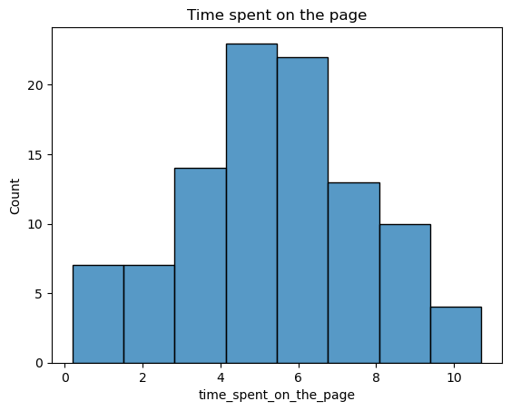

```python
sns.histplot(data=df, x='time_spent_on_the_page')
plt.title('Time spent on the page')
plt.show()
```

- Time spent on the page is following a normal distribution
- The average time spent on the page is around 5 minutes

#### Converted

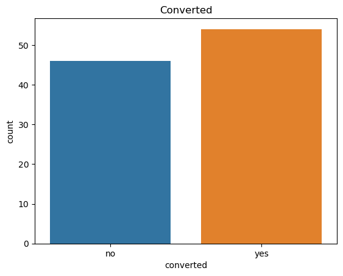

```python
sns.countplot(data=df, x='converted')
plt.title('Converted')
plt.show()
```

```python
df['converted'].value_counts()
```

```
yes    54
no     46
Name: converted, dtype: int64
```

- 54 users in total converted to a subscriber of the news portal
- 46 users in total did not convert to a subscriber of the news portal
- The users who converted and did not convert are distributed almost half and half

#### Language Prefered

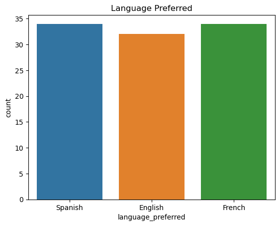

```python
sns.countplot(data=df, x='language_preferred')
plt.title('Language Preferred')
plt.show()
```

```python
df['language_preferred'].value_counts()
```

```
Spanish    34
French     34
English    32
Name: language_preferred, dtype: int64
```

- The most preferred language by users is Spanish and French
- The least preferred language by users is English

### Bivariate Analysis

#### Group & Converted

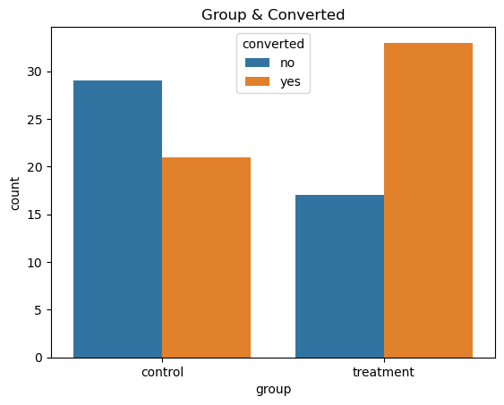

```python
sns.countplot(data=df, x='group', hue='converted')
plt.title('Group & Converted')
plt.show()
```

- The users in the treatment group tend to convert to subscribers of the new portal more than the ones in the control group
- There are more users that did not convert in the control group than the ones who did convert
- There are more users that convert in the treatment group than the ones who did not convert

#### Landing Page & Time spent on the page

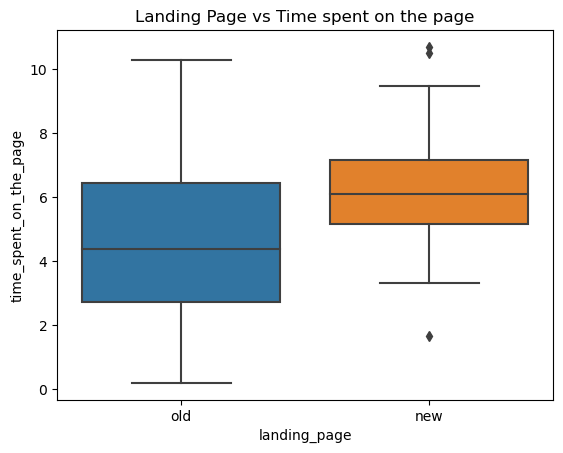

```python
sns.boxplot(data=df, x='landing_page', y='time_spent_on_the_page')
plt.title('Landing Page vs Time spent on the page')
plt.show()
```

- On average, the new landing page has the most time spent on the page by users
- The old landing page has a maximum spent time a little over 10 minutes and a minimum spent time of less than a minute.
- The new landing page has outliers, where users spent more than 10 minutes and les than 2 minutes on the page

#### Time spent vs Converted

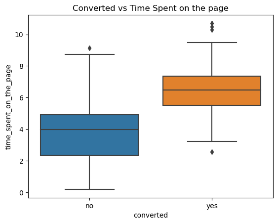

```python
sns.boxplot(data=df, x='converted', y='time_spent_on_the_page')
plt.title('Converted vs Time Spent on the page')
plt.show()
```

- On average, the users who converted spent more time on the page than the ones who did not convert

#### Language vs Time spent on the page

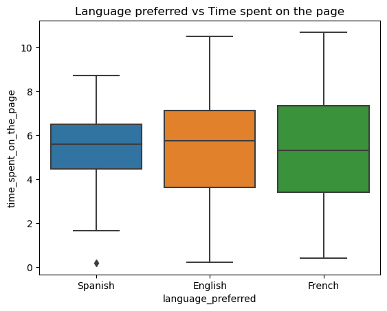

```python
sns.boxplot(data=df, x='language_preferred', y='time_spent_on_the_page')
plt.title('Language preferred vs Time spent on the page')
plt.show()
```

- It seems like the average time spent on the page doesn't vary depending on the language preferred.

## 1. Do the users spend more time on the new landing page than the existing landing page?

### Perform Visual Analysis

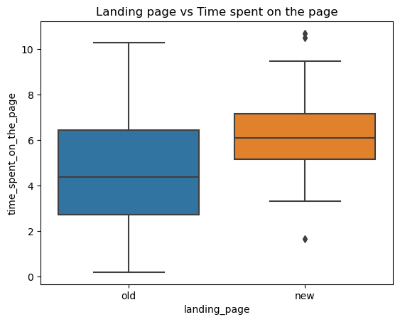

```python
sns.boxplot(data=df, x='landing_page', y='time_spent_on_the_page')
plt.title('Landing page vs Time spent on the page')
plt.show()
```

### Step 1: Define the null and alternate hypotheses

$H_0$: Users spend more time on the existing page ($\mu_1$) than on the new landing page ($\mu_2$)

$H_a$: Users spend more time on the new landing ($\mu_2$) page than on the existing page ($\mu_1$)

$H_0$: $\mu_1$ $\ge$ $\mu_2$

$H_a$: $\mu_1$ < $\mu_2$

### Step 2: Select Appropriate test

We are comparing the sample means of 2 independent populations where the standard deviations are unknown. Based on this information, the appropriate test in this case is a **2 sample independent t-test**.

### Step 3: Decide the significance level

According to the problem statement, we are using a significance level of $\alpha = 0.05$

### Step 4: Collect and prepare data

```python
time_old = df[df['landing_page']=='old']['time_spent_on_the_page']
time_new = df[df['landing_page']=='new']['time_spent_on_the_page']
```

```python
# find the sample means and sample standard deviations for the two samples
print('The mean time spent on the old landing page is', round(time_old.mean(),2))
print('The mean time spent on the new landing page is', round(time_new.mean(),2))
print('The standard deviation of the time spent on the old landing page is', round(time_old.std(),2))
print('The standard deviation of the time spent on the new landing page is', round(time_new.std(),2))
```

```
The mean time spent on the old landing page is 4.53
The mean time spent on the new landing page is 6.22
The standard deviation of the time spent on the old landing page is 2.58
The standard deviation of the time spent on the new landing page is 1.82
```

### Step 5: Calculate the p-value

```python
# import the appropriate test function
from scipy.stats import ttest_ind

# find the p value
test_stat, p_value = ttest_ind(time_old, time_new, equal_var=False, alternative='less')
print('The p value is', p_value)
```

```
The p value is 0.00013923812251665497
```

### Step 6: Compare the p-value with $\alpha$

The p-value is around 0.00014, which is less than the level of significance of $\alpha = 0.05$.

0.00014 < 0.05

### Step 7: Draw inference

Since p-value is less than the level of significance (0.05) we can reject the null hypothesis. Hence, we can say that we have enough evidence to support that **the users spend more time on the new landing page than on the existing one**.

## 2. Is the conversion rate (the proportion of users who visit the landing page and get converted) for the new page greater than the conversion rate for the old page?

### Visual Analysis

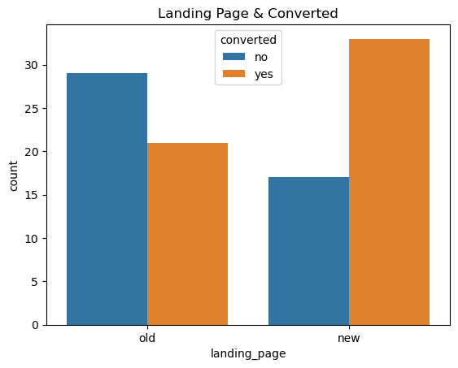

```python
sns.countplot(data=df, x='landing_page', hue='converted')
plt.title('Landing Page & Converted')
plt.show()
```

### Step 1: Define the null and alternate hypotheses

$H_0$: The conversion rate for the new page ($p_1$) is less than or equal to the conversion rate for the old page ($p_2$).

$H_a$: The conversion rate for the new page ($p_1$) is greater than the conversion rate for the old page ($p_2$).

$H_0: p_1 \le p_2$

$H_a: p1 > p2$

### Step 2: Select Appropriate test

We are comparing the sample proportions on two independent populations. Hence, the appropriate test for this is a **2 proportion z-test**.

### Step 3: Decide the significance level

According to the problem statement, we are using a significance level of $\alpha = 0.05$

### Step 4: Collect and prepare data

```python
# create new variables that include type of page and if converted or not
convert_new = df[df['landing_page']=='new']['converted']
convert_old = df[df['landing_page']=='old']['converted']
```

```python
convert_new.value_counts()
```

```
yes    33
no     17
Name: converted, dtype: int64
```

```python
convert_old.value_counts()
```

```
no     29
yes    21
Name: converted, dtype: int64
```

33 out of 50 users converted to the new page

21 out of 50 users converted to the old page

### Step 5: Calculate the p-value

```python
# import the appropriate test function
from statsmodels.stats.proportion import proportions_ztest

# set the count of successes
count = np.array([33,21])

# set the sample sizes
nobs = np.array([50,50])

# find the p value
test_stat, p_value = proportions_ztest(count, nobs, alternative='larger')
print('The p-value is', (p_value))
```

```
The p-value is 0.008026308204056278
```

### Step 6: Compare the p-value with $\alpha$

The p-value is around 0.008, which is less than the level of significance of 0.05.

0.008 < 0.05

### Step 7: Draw inference

Since p-value is less than the level of significance (0.05) we can reject the null hypothesis. Hence, we have enough evidence to support that **the conversion rate for the new page is greater than the conversion rate for the old page**.

## 3. Is the conversion and preferred language are independent or related?

### Visual Analysis

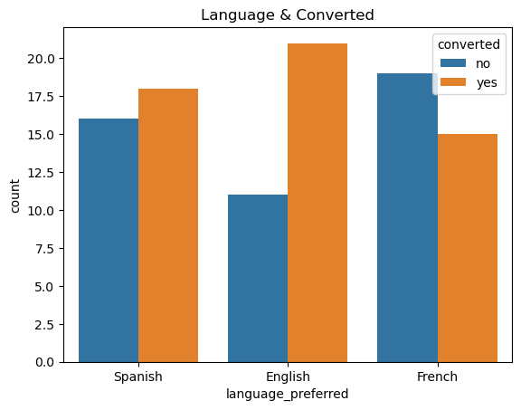

```python
sns.countplot(data=df, x='language_preferred', hue='converted')
plt.title('Language & Converted')
plt.show()
```

### Step 1: Define the null and alternate hypotheses

$H_0$: The conversion is independent from the language preferred by the user.

$H_a$: The conversion depends on the language preferred by the user.

### Step 2: Select Appropriate test

Since we are comparing the independence of two categorical variables, we will use the **chi-square test of independence**.

### Step 3: Decide the significance level

According to the problem statement, we are using a significance level of $\alpha = 0.05$

### Step 4: Collect and prepare data

```python
# create a contingency table that includes converted and language preferred
contingency_table = pd.crosstab(df['converted'], df['language_preferred'])
contingency_table
```

| language_preferred converted | English | French | Spanish |
| --- | --- | --- | --- |
| no | 11 | 19 | 16 |
| yes | 21 | 15 | 18 |

### Step 5: Calculate the p-value

```python
#import the appropriate function test
from scipy.stats import chi2_contingency

#find the p value
chi, p_value, dof, expected = chi2_contingency(contingency_table)
print('The p-value is ' +str(p_value))
```

```
The p-value is 0.21298887487543447
```

### Step 6: Compare the p-value with $\alpha$

The p-value is around 0.213, which is greater than the significance level of 0.05

0.213 > 0.05